# Assignment6_JumpingJacks

Yingxin Ye |yy2649

# Task I

You will be working in groups on a quantified student project Download the Sensor Kinetics Pro app to your iOS or Android device (or similar gyroscope measuring app) Split into subgroups with each subgroup investigating one measures available in the app Each subgroup should report back after 20min with what they have learned

# Task II

1. In consultation with your group select a physical activity that: a) can be measured using the app, b) has a concrrete, sontinuous, countable outcome and c) some members of the group are experts and some are novices at - If you are looking for inspiration you can find previous student projects below.

Describe our project: The physical activity we choose was jumping jacks. We measured how many Jumping Jacks we did in 30s during the Hackathon on December 2nd, 2020. While we performing jumping jacks, we held a cell phone with our right hand to record the movement data. We self reported how often do we do jumping jacks at a 1-5 scale, this can be used to differentiate novice and expert in the group.

**Maybe we can use Q2 in the survey to define novices and experts??

2. Collect measurements for all members of the group performing the task using the app

In this project, we used the App “Physics Toolbox Sensor Suite”. We used the gyroscope function in the app to record position change while we were performing jumping jacks in 30s.

3. Create a Github repo where you can store and share your data https://github.com/zjf2003tc/Assignment6_JumpingJacks
4. Using K-means, can you identify the novices from the experts using only the app data?

To perform cluster analysis, we transferred the raw data to the distance differences/sum of total distance for each participant. The results doesn’t seem like match with Q2

5. Visualize your results using ggplot2

# Set up

```r
library(dplyr)
```

```r
library(tidyr)
library(ggplot2)
library(GGally)
#import data
DFge<-read.csv("sensor_Ge.csv")
DFlee<-read.csv("sensor_lee.csv")
DFye<-read.csv("sensor_ye.csv")
DFzhang<-read.csv("sensor_Zhang.csv")
DFfriedman<-read.csv("sensor_friedman.csv")
DFzhao<-read.csv("sensor_zhao.csv")
DFdanny<-read.csv("sensor_Danny.csv")
DFsang<-read.csv("sensor_Sang.csv")
```

# Merging data

```r
DFge$name<-c("ge")
DFlee$name<-c("lee")
DFye$name<-c("ye")
DFzhang$name<-c("zhang")
DFfriedman$name<-c("friedman")
DFzhao$name<-c("zhao")
DFdanny$name<-c("danny")
DFsang$name<-c("sang")

colnames(DFlee)<-c("time","wx","wy","wz","name" )
DF <- rbind(DFge, DFlee,DFye,DFzhang,DFfriedman,DFzhao,DFdanny,DFsang)
DF$wx<-abs(DF$wx)
DF$wy<-abs(DF$wy)
DF$wz<-abs(DF$wz)

dd<-DF %>% group_by(name) %>% summarise(diffx=max(wx)-min(wx),diffy=max(wy)-min(wy),diffz=max(wz)-min(wz))
ds<-DF %>% group_by(name) %>% summarise(sumx=sum(wx),sumy=sum(wy),sumz=sum(wz))
```

# Clustering

```r
dd1<-data.frame(dd)
dd2 <- dd1[,2:4]
dd3<-scale(dd2, center = TRUE, scale = TRUE)
fitdd <- kmeans(dd3,2)
dd4<-data.frame(dd1,fitdd$cluster)

ds1<-data.frame(ds)
ds1<-ds1[-4,]#lee is an outlier, probably due to unit difference
ds2 <- ds1[,2:4]
ds3<-scale(ds2, center = TRUE, scale = TRUE)
fitds <- kmeans(ds3,2)
ds4<-data.frame(ds1,fitds$cluster)
```

# Cluster visualization

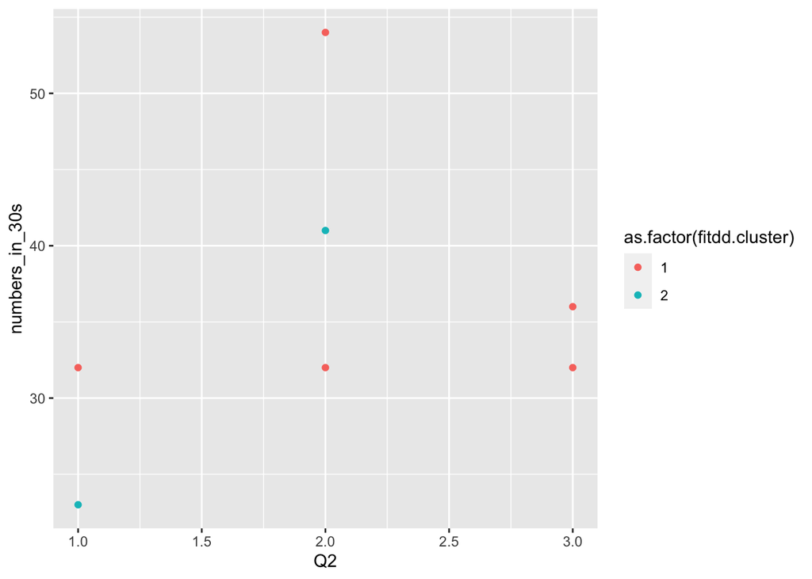

```r
number30s<-read.csv("Jumping_Jacks_in_30s.csv")
sr<-read.csv("SurveyResponse.csv")
dd5<-merge(dd4,number30s,by=c("name"))
dd5<-merge(dd5,sr,by=c("name"))
ds5<-merge(ds4,number30s,by=c("name"))
ds5<-merge(ds5,sr,by=c("name"))

#numbers in 30s by how often perform jumping jacks
qplot(Q2,numbers_in_30s,col=as.factor(fitdd.cluster),data=dd5)
```

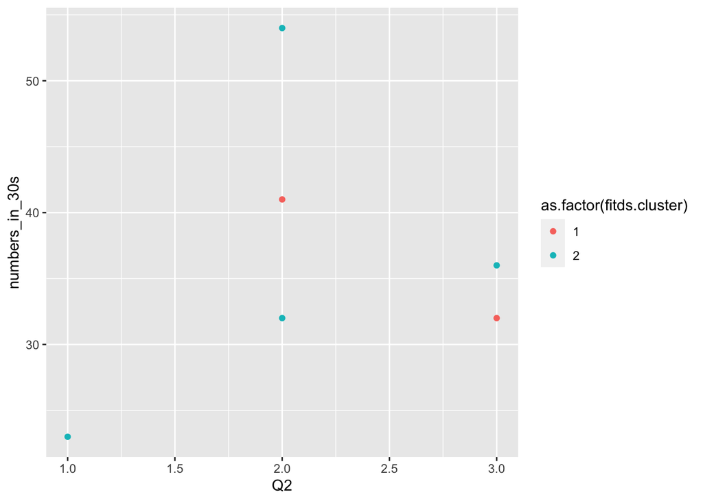

```r
qplot(Q2,numbers_in_30s,col=as.factor(fitds.cluster),data=ds5)
```

# Task III 1. Devise five questions on a five point Likert scale that ask members of your group about their experience with your chosen task Collect data from all members of your group

Q1.I consider myself physically fit. Q2.I regularly do jumping jacks. Q3.I eat a nutritious and balanced diet. Q4.I performed at my average ability during the test. Q5.I have good jumping jack technique/form

2. Run a PCA analysis on the data
3. What does PC1 represent in your analysis?

Based on the loadings output, it seems like PC1 represent Q1, Q2 and Q5, which are more related to ability to perform jumping jacks rather than status of body at the moment of performing jumping jacks.

4. Visualize the PC1 results for each member of your group ?? not sure

PCA

```r
sr1<-na.omit(sr) #Danny didn't fill out the survey
sr2<-sr1[,-1]

pca <- prcomp(sr2, scale. = TRUE)
summary(pca)
```

```
## Importance of components:
##                           PC1    PC2    PC3     PC4     PC5
## Standard deviation     1.5406 1.1745 0.8717 0.53794 0.44490
## Proportion of Variance 0.4747 0.2759 0.1520 0.05788 0.03959
## Cumulative Proportion  0.4747 0.7506 0.9025 0.96041 1.00000
```

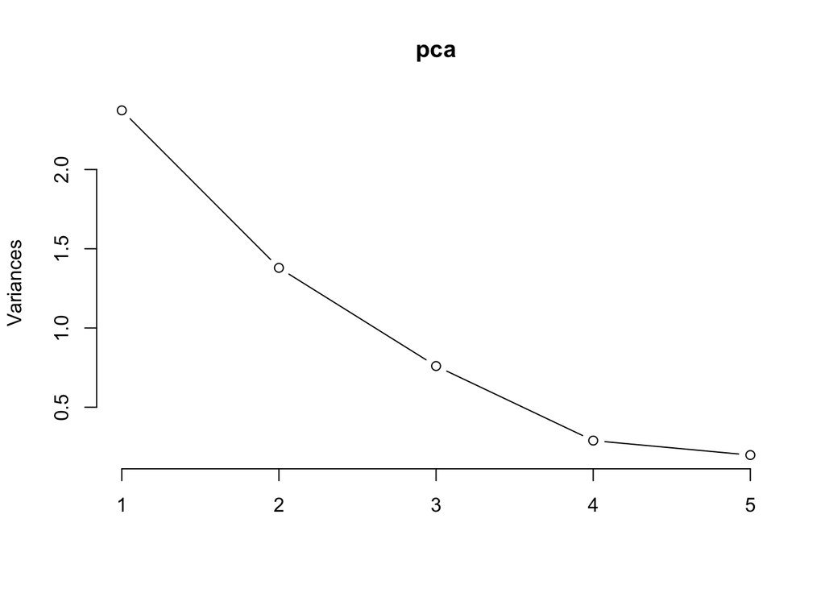

```r
plot(pca, type = "lines")
```

```r
loadings <- abs(pca$rotation)
loadings
```

```
##          PC1       PC2         PC3        PC4        PC5
## Q1 0.5385820 0.3794482 0.008998301 0.09739393 0.74591013
## Q2 0.4429310 0.5426641 0.190107827 0.27682707 0.62972498
## Q3 0.2487424 0.5138705 0.790790102 0.21130715 0.06375409
## Q4 0.3762336 0.4911406 0.571307585 0.53032325 0.09794919
## Q5 0.5570610 0.2371764 0.109711906 0.76680358 0.18277281
```

```r
pca$x
```

```
##          PC1        PC2         PC3        PC4          PC5
## 1 -2.3705050 -1.6995341  0.31145758 -0.1143405 -0.246539388
## 3  0.3165277 -0.8155589  0.05761755  0.2086422  0.816329571
## 4 -0.9044892  1.2387357 -0.77250012  0.4503590  0.276450666
## 5  2.2093880 -0.5661130  0.60022663  0.6543228 -0.371862714
## 6 -0.3620117  0.5741106 -1.00533370  0.1113165 -0.494801773
## 7  1.5735852 -0.2971278 -0.63591694 -0.9533530  0.029047810
## 8 -0.4624949  1.5654876  1.44444900 -0.3569471 -0.008624173
```

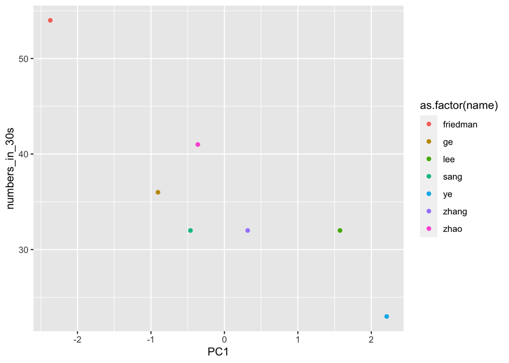

```r
pcax<-pca$x
name=c("friedman","zhang","ge","ye","zhao","lee", "sang")
pcax<-data.frame(pcax,name=name)

#merging distance difference data with other data
dd6<-merge(sr1,pcax,by=c("name"))
dd6<-merge(dd6,dd5[-1,],by=c("name"))

qplot(PC1,numbers_in_30s,col=as.factor(name),data=dd6)
```

## Task IV

1. If you could only choose one thing to predict the score for each member of your group (raw data variable, a cluster or a PC) what would it be and why?

Based on the correlation graph, both PC1 and Q5 have a high correlation with number of jumping jacks in 30s, so PC1 (Q1,Q2,Q5) could be a good predictor, especially Q5. How good do we feel about our techniques would predict how well do we perform jumping jacks in this case.

2. Create a visualization that supports your conclusion
3. Based on your conclusion devise an intervention that would help novice members of your group improve their performance

Practice more regularly

# Prediction

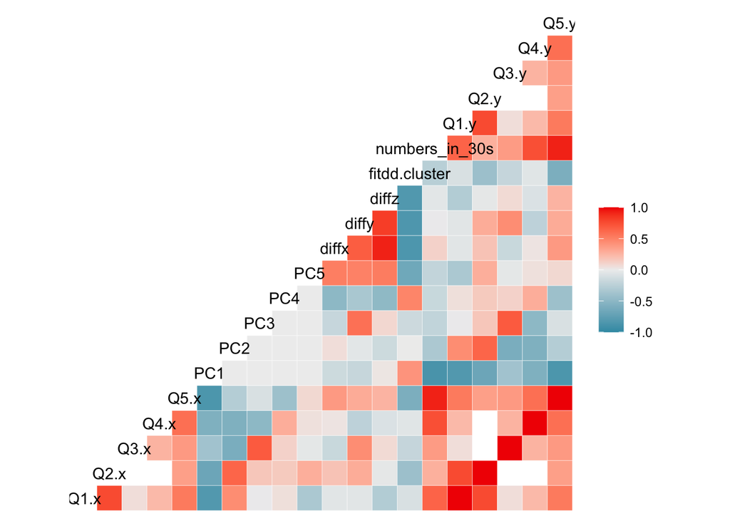

```r
ggcorr(dd6, method = c("everything", "pearson"))
```